# MPDW Pertemuan 6

Wildy Fahmi Rosyidi G1401231066

2025-10-01

```r
library(ggplot2)
library(tsibble)
library(tseries)
library(MASS)
library(rio)
library(forecast)
library(TSA)
library(TTR)
library(aTSA)
library(graphics)
```

## Input Data

```r
data_mpdw <- import("https://raw.githubusercontent.com/nyayunabila/mpdw/refs/heads/main/data%20kelompok%209%20-%20Sheet1.csv")
head(data_mpdw)
```

```
##         date daily_revenue
## 1 19/08/2023        334,32
## 2 20/08/2023        140,92
## 3 21/08/2023        296,88
## 4 22/08/2023        157,86
## 5 23/08/2023        211,18
## 6 24/08/2023         76,58
```

```r
data_301to400 <- data_mpdw[301:400, ]
data_301to400
```

```
##           date daily_revenue
## 301 14/06/2024        312,55
## 302 15/06/2024        151,53
## 303 16/06/2024        246,88
## 304 17/06/2024        234,16
## 305 18/06/2024         219,8
## 306 19/06/2024        217,96
## 307 20/06/2024        159,64
## 308 21/06/2024        210,33
## 309 22/06/2024         118,2
## 310 23/06/2024         271,7
## 311 24/06/2024        328,04
## 312 25/06/2024        337,63
## 313 26/06/2024         279,3
## 314 27/06/2024        294,11
```

[output cut: 86 more lines]

## Plot Time Series

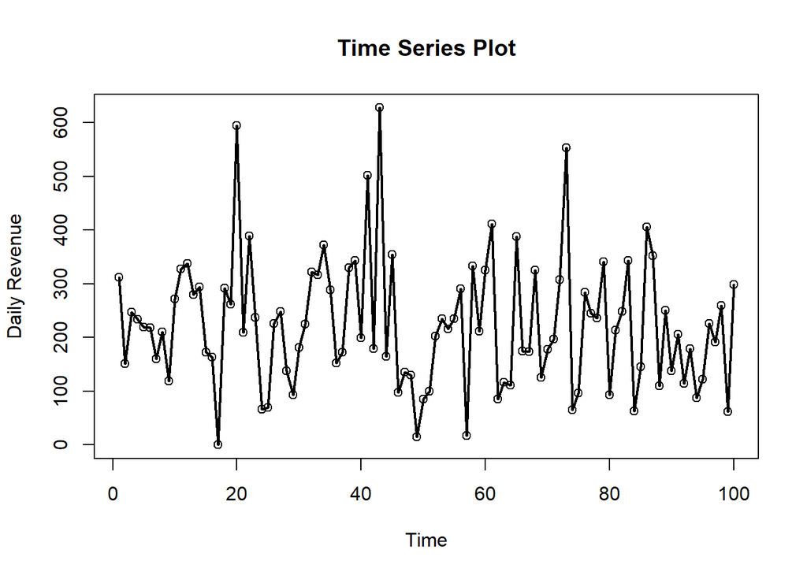

```r
data_301to400$daily_revenue <- gsub(",", ".", data_301to400$daily_revenue)

data_301to400$daily_revenue <- as.numeric(data_301to400$daily_revenue)

data_pertemuan5 <- ts(data_301to400$daily_revenue)

ts.plot(data_pertemuan5,
        xlab="Time",
        ylab="Daily Revenue",
        main="Time Series Plot",
        lwd=2)
points(data_pertemuan5)
```

### Data Latih

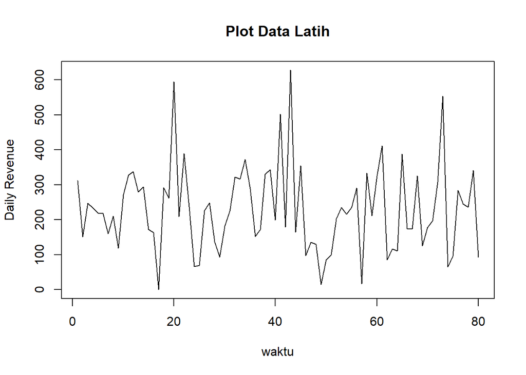

```r
data5_train<-data_301to400[1:80, ]
train.ts<-ts(data5_train$daily_revenue)
plot.ts(train.ts, lty=1, xlab="waktu", ylab="Daily Revenue", main="Plot Data Latih")
```

### Data Uji

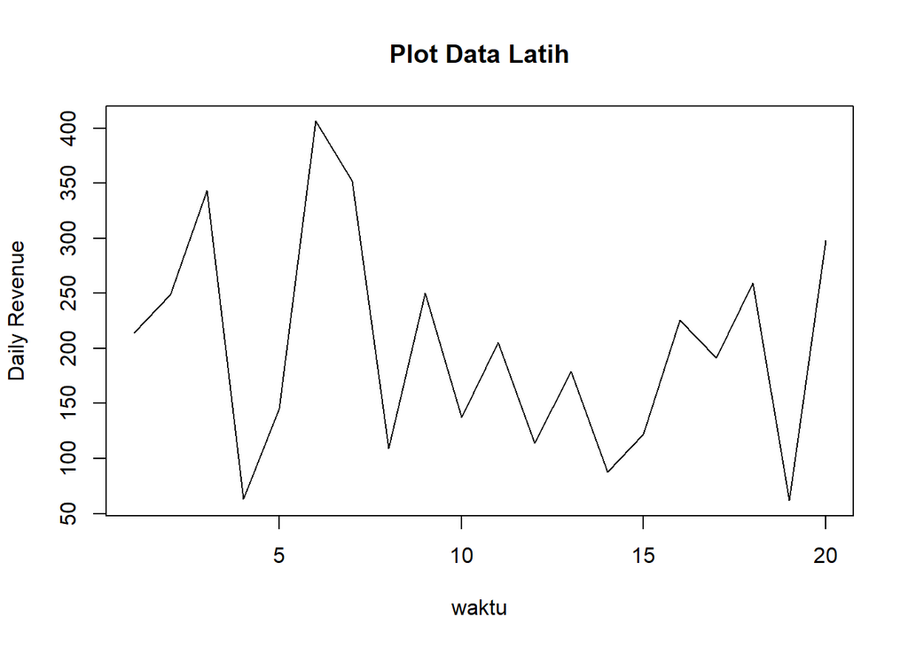

```r
data5_test<-data_301to400[81:100, ]
test.ts<-ts(data5_test$daily_revenue)
plot.ts(test.ts, lty=1, xlab="waktu", ylab="Daily Revenue", main="Plot Data Latih")
```

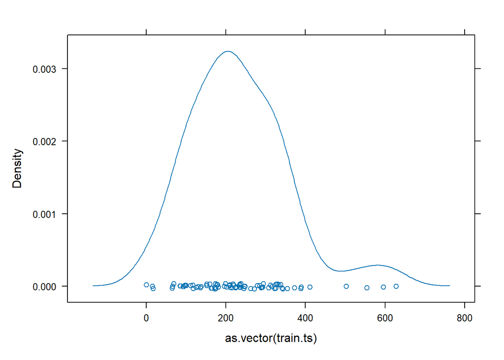

```r
lattice::densityplot(as.vector(train.ts))
```

Dari grafik diatas terlihat masih terdapat beberapa pencilan pada data.

## Uji Stasioner Dalam Rataan dan Ragam

### ACF

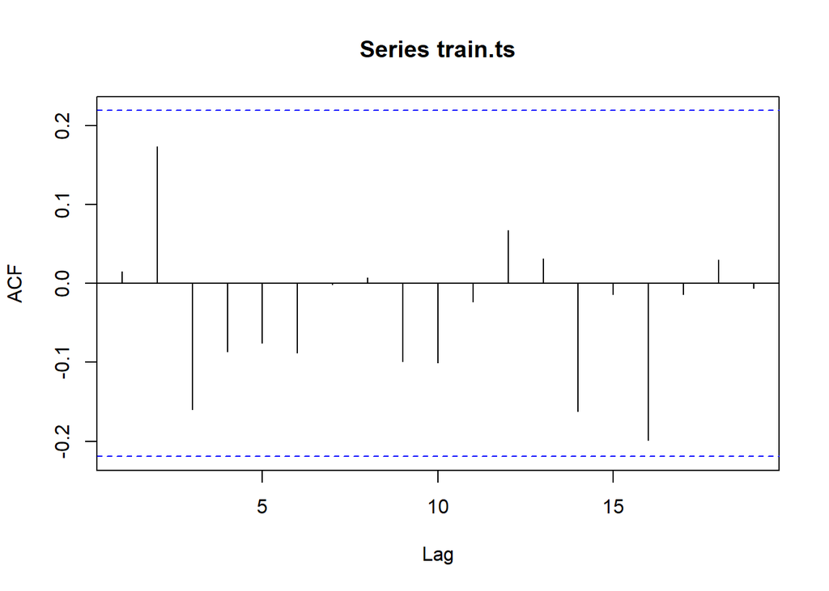

```r
acf(train.ts)
```

### Uji ADF

```r
tseries::adf.test(train.ts)
```

```
##
##  Augmented Dickey-Fuller Test
##
## data:  train.ts
## Dickey-Fuller = -4.1835, Lag order = 4, p-value = 0.01
## alternative hypothesis: stationary
```

Karena p-value < 0,05 menandakan bahwa data sudah stasioner dalam rataan.

### Plot Box-Cox

Bila ingin membuat plot box-cox pastikan variabel y nya tidak ada yang 0. Maka akan dicek apakah ada variabel y yang bernilai 0.

```r
any(data5_train$daily_revenue == 0)
```

```
## [1] TRUE
```

Ternyata ada data yang bernilai 0. Agar data tidak ada yang berniali 0 maka akan dijumlahkan dengan 1.

```r
train_ts_geser <- train.ts + 1
```

```r
train_ts_geser
```

```
## Time Series:
## Start = 1
## End = 80
## Frequency = 1
##  [1] 313.55 152.53 247.88 235.16 220.80 218.96 160.64 211.33 119.20 272.70
## [11] 329.04 338.63 280.30 295.11 173.07 164.08   1.00 293.44 262.96 596.38
## [21] 210.12 390.44 238.52  67.03  70.44 226.72 248.96 138.46  93.56 181.87
## [31] 225.82 323.65 317.24 373.18 289.38 152.94 173.84 330.47 344.26 200.20
## [41] 503.25 180.54 628.94 165.97 355.71  98.76 136.56 131.10  16.12  85.82
## [51] 100.81 203.18 235.43 216.46 235.62 291.71  18.12 334.18 212.20 326.10
## [61] 412.14  86.58 117.76 112.24 389.38 175.54 174.40 326.62 126.09 178.55
## [71] 197.53 308.65 555.03  65.98  97.43 285.40 245.95 237.55 342.25  94.38
```

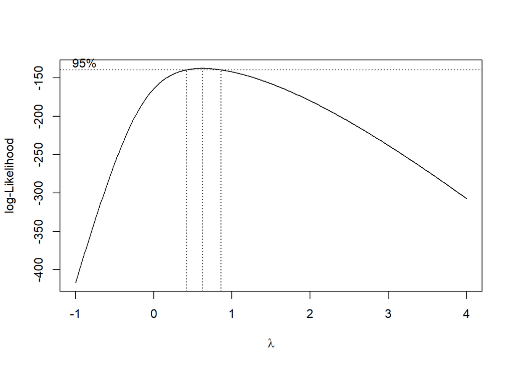

```r
index <- seq(1:80)
bc = boxcox(train_ts_geser ~ index, lambda = seq(-1,4,by=0.01))
```

```r
lambda <- bc$x[which.max(bc$y)]
lambda
```

```
## [1] 0.62
```

```r
bc$x[bc$y > max(bc$y) - 1/2 * qchisq(.95,1)]
```

```
##  [1] 0.42 0.43 0.44 0.45 0.46 0.47 0.48 0.49 0.50 0.51 0.52 0.53 0.54 0.55 0.56
## [16] 0.57 0.58 0.59 0.60 0.61 0.62 0.63 0.64 0.65 0.66 0.67 0.68 0.69 0.70 0.71
## [31] 0.72 0.73 0.74 0.75 0.76 0.77 0.78 0.79 0.80 0.81 0.82 0.83 0.84 0.85
```

### Transformasi Box-cox

Karena lambda optimum nya mendekati nilai `0,5` maka akan dilakukan transformasi akar terhadap daily revenue

```r
data_boxcox <- train_ts_geser^0.5
```

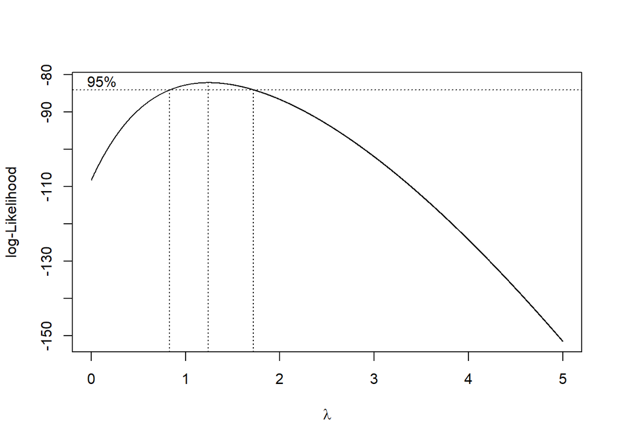

```r
index <- seq(1:80)

bc2 <- boxcox(
  data_boxcox ~ index,
  lambda = seq(0, 5, by = 0.001)
)
```

```r
lambda <- bc2$x[which.max(bc2$y)]
lambda
```

```
## [1] 1.243
```

```r
ci_lambda <- bc2$x[bc2$y > max(bc2$y) - 0.5 * qchisq(0.95, 1)]

ci_lower <- min(ci_lambda)
ci_upper <- max(ci_lambda)

c(Batas_Bawah = ci_lower, Batas_Atas = ci_upper)
```

```
## Batas_Bawah  Batas_Atas
##       0.833       1.719
```

Setelah dilakukan transformasi box-cox terlihat bahwa data sudah stasioner dalam ragam.

### Pengecekan Ulang

Untuk memastikan, akan dilakukan pengujian ulang kestasioneran dalam rataan terhadap model yang sudah transformasi

#### ACF

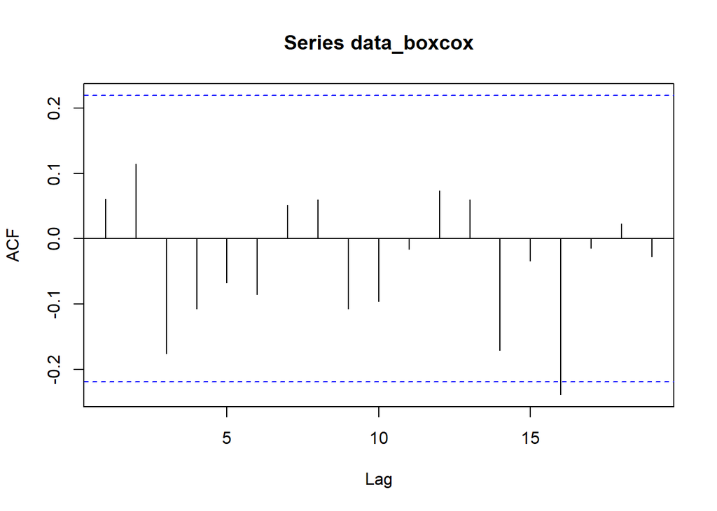

```r
acf(data_boxcox)
```

#### Uji ADF

```r
tseries::adf.test(data_boxcox)
```

```
##
##  Augmented Dickey-Fuller Test
##
## data:  data_boxcox
## Dickey-Fuller = -4.2789, Lag order = 4, p-value = 0.01
## alternative hypothesis: stationary
```

Karena p-value < 0.05. Maka data setelah transformasi sudah stasioner dalam rataan dan juga dalam ragam.

## Identifikasi Model

### Plot ACF

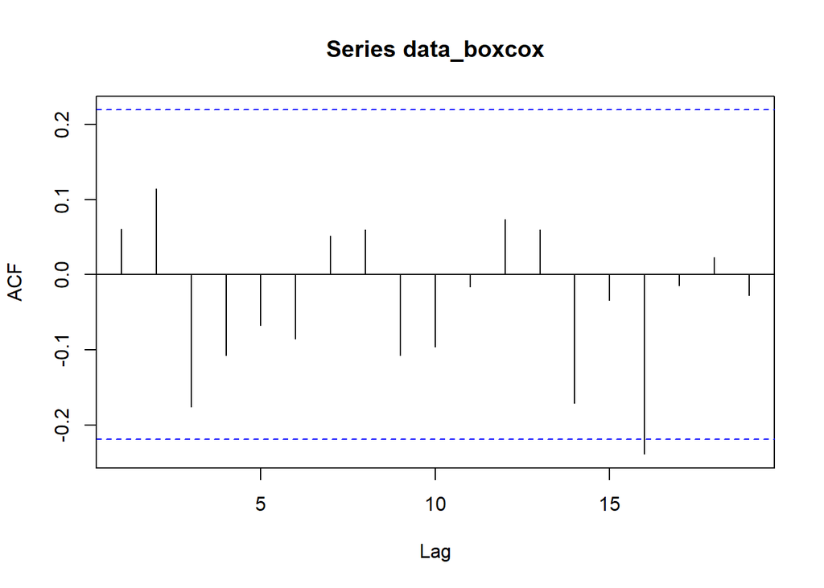

```r
acf(data_boxcox)
```

ACF cenderung tails-off

### Plot PACF

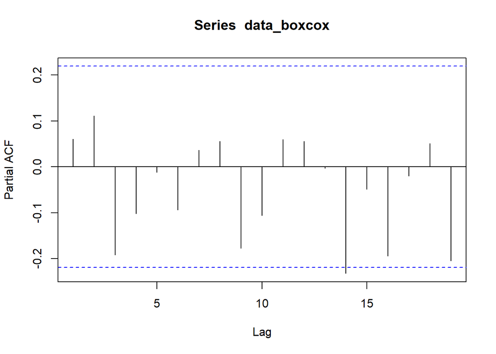

```r
pacf(data_boxcox)
```

PACF nya juga cenderung tails-off

### Plot EACF

```r
eacf(data_boxcox)
```

```
## AR/MA
##   0 1 2 3 4 5 6 7 8 9 10 11 12 13
## 0 o o o o o o o o o o o  o  o  o
## 1 x o o o o o o o o o o  o  o  o
## 2 x x o o o o o o o o o  o  o  o
## 3 x o x o o o o o o o o  o  o  o
## 4 o o o x o o o o o o o  o  o  o
## 5 o x o o o o o o o o o  o  o  o
## 6 x x o o o x o o o o o  o  o  o
## 7 x o x o o x o o o o o  o  o  o
```

Dari eacf diatas didapatkan beberapa model, seperti ARIMA(0,0,0), ARIMA(1,0,1), ARIMA(2,0,2), dan ARIMA(3,0,3)

## Pendugaan Parameter Model

### ARIMA(0,0,0)

```r
model1.da=Arima(data_boxcox, order=c(0,0,0),method="ML")
summary(model1.da)
```

```
## Series: data_boxcox
## ARIMA(0,0,0) with non-zero mean
##
## Coefficients:
##          mean
##       14.5817
## s.e.   0.4809
##
## sigma^2 = 18.73:  log likelihood = -230.22
## AIC=464.45   AICc=464.6   BIC=469.21
##
## Training set error measures:
##                        ME     RMSE      MAE       MPE     MAPE      MASE
## Training set 9.992007e-16 4.300986 3.290156 -26.69421 43.73626 0.7590259
##                    ACF1
## Training set 0.06025872
```

```r
lmtest::coeftest(model1.da)
```

```
##
## z test of coefficients:
##
##           Estimate Std. Error z value  Pr(>|z|)
## intercept 14.58167    0.48087  30.324 < 2.2e-16 ***
## ---
## Signif. codes:  0 '***' 0.001 '**' 0.01 '*' 0.05 '.' 0.1 ' ' 1
```

### ARIMA(1,0,1)

```r
model2.da=Arima(data_boxcox, order=c(1,0,1),method="ML")
summary(model2.da)
```

```
## Series: data_boxcox
## ARIMA(1,0,1) with non-zero mean
##
## Coefficients:
##          ar1      ma1     mean
##       0.2779  -0.2080  14.5801
## s.e.  0.5339   0.5349   0.5252
##
## sigma^2 = 19.12:  log likelihood = -230.01
## AIC=468.02   AICc=468.56   BIC=477.55
##
## Training set error measures:
##                        ME     RMSE      MAE       MPE     MAPE      MASE
## Training set -0.003162788 4.289511 3.304423 -26.51159 43.65172 0.7623173
##                     ACF1
## Training set -0.01342244
```

```r
lmtest::coeftest(model2.da)
```

```
##
## z test of coefficients:
##
##           Estimate Std. Error z value Pr(>|z|)
## ar1        0.27791    0.53389  0.5205   0.6027
## ma1       -0.20798    0.53489 -0.3888   0.6974
## intercept 14.58013    0.52523 27.7596   <2e-16 ***
## ---
## Signif. codes:  0 '***' 0.001 '**' 0.01 '*' 0.05 '.' 0.1 ' ' 1
```

### ARIMA(2,0,2)

```r
model3.da=Arima(data_boxcox, order=c(2,0,2),method="ML")
summary(model3.da)
```

```
## Series: data_boxcox
## ARIMA(2,0,2) with non-zero mean
##
## Coefficients:
##           ar1      ar2     ma1     ma2     mean
##       -0.8027  -0.7256  0.8767  1.0000  14.6021
## s.e.   0.0990   0.0911  0.0494  0.0758   0.5075
##
## sigma^2 = 17.01:  log likelihood = -226.33
## AIC=464.66   AICc=465.81   BIC=478.96
##
## Training set error measures:
##                        ME     RMSE      MAE       MPE     MAPE      MASE
## Training set -0.006629967 3.993713 3.220928 -23.86685 41.07769 0.7430553
##                    ACF1
## Training set 0.03476395
```

```r
lmtest::coeftest(model3.da)
```

```
##
## z test of coefficients:
##
##            Estimate Std. Error z value  Pr(>|z|)
## ar1       -0.802700   0.098984 -8.1094 5.087e-16 ***
## ar2       -0.725576   0.091099 -7.9647 1.656e-15 ***
## ma1        0.876726   0.049402 17.7469 < 2.2e-16 ***
## ma2        0.999998   0.075839 13.1858 < 2.2e-16 ***
## intercept 14.602117   0.507464 28.7747 < 2.2e-16 ***
## ---
## Signif. codes:  0 '***' 0.001 '**' 0.01 '*' 0.05 '.' 0.1 ' ' 1
```

### ARIMA(3,0,3)

```r
model4.da=Arima(data_boxcox, order=c(3,0,3),method="ML")
summary(model4.da)
```

```
## Series: data_boxcox
## ARIMA(3,0,3) with non-zero mean
##
## Coefficients:
##          ar1      ar2     ar3      ma1     ma2      ma3     mean
##       0.1949  -0.0509  0.5397  -0.2250  0.1252  -0.9000  14.5638
## s.e.  0.3171   0.1726  0.2191   0.2379  0.1046   0.1801   0.1283
##
## sigma^2 = 17:  log likelihood = -224.63
## AIC=465.25   AICc=467.28   BIC=484.31
##
## Training set error measures:
##                     ME    RMSE      MAE       MPE     MAPE      MASE       ACF1
## Training set 0.1738293 3.93842 3.097641 -21.28035 38.79951 0.7146136 0.03993769
```

```r
lmtest::coeftest(model4.da)
```

```
##
## z test of coefficients:
##
##            Estimate Std. Error  z value  Pr(>|z|)
## ar1        0.194939   0.317078   0.6148   0.53869
## ar2       -0.050904   0.172599  -0.2949   0.76805
## ar3        0.539711   0.219051   2.4639   0.01375 *
## ma1       -0.224964   0.237929  -0.9455   0.34440
## ma2        0.125206   0.104624   1.1967   0.23142
## ma3       -0.899979   0.180054  -4.9984 5.781e-07 ***
## intercept 14.563752   0.128260 113.5489 < 2.2e-16 ***
## ---
## Signif. codes:  0 '***' 0.001 '**' 0.01 '*' 0.05 '.' 0.1 ' ' 1
```

## Analisis Sisaan

### Eksplorasi Sisaan

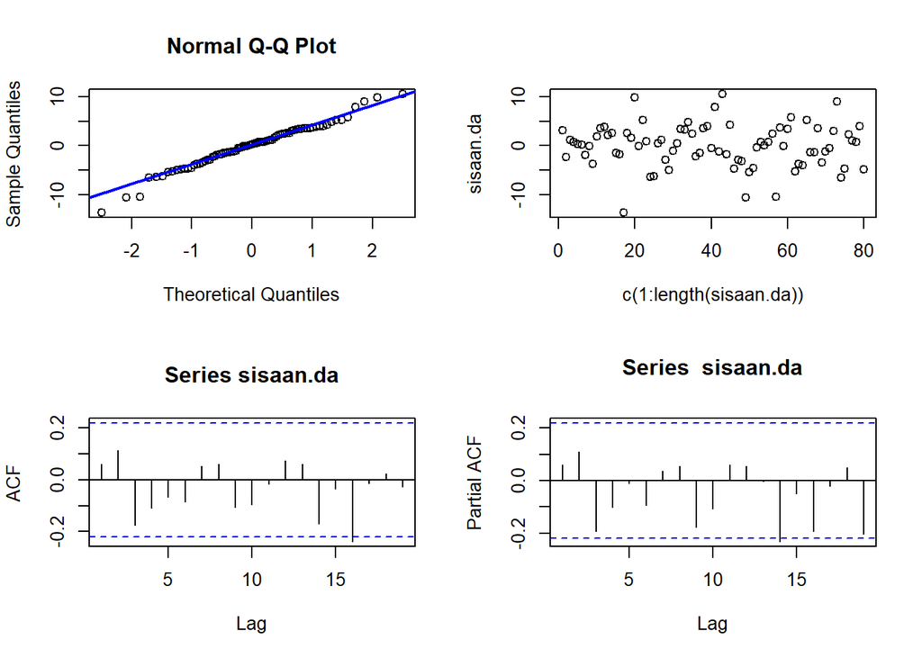

```r
sisaan.da <- model1.da$residuals
par(mfrow=c(2,2))
qqnorm(sisaan.da)
qqline(sisaan.da, col = "blue", lwd = 2)
plot(c(1:length(sisaan.da)),sisaan.da)
acf(sisaan.da)
pacf(sisaan.da)
```

```r
par(mfrow = c(1,1))
```

### Uji Formal

```r
ks.test(sisaan.da,"pnorm")
```

```
##
##  Exact one-sample Kolmogorov-Smirnov test
##
## data:  sisaan.da
## D = 0.32332, p-value = 6.071e-08
## alternative hypothesis: two-sided
```

p-value < 0.05. Maka kita menolak H0, artinya sisaan tidak menyebar secara normal

```r
Box.test(sisaan.da, type = "Ljung")
```

```
##
##  Box-Ljung test
##
## data:  sisaan.da
## X-squared = 0.30152, df = 1, p-value = 0.5829
```

karena p-value > 0.05. Maka kita gagal menolak H0, yang berarti sisaan saling bebas

```r
Box.test((sisaan.da)^2, type = "Ljung")
```

```
##
##  Box-Ljung test
##
## data:  (sisaan.da)^2
## X-squared = 0.43951, df = 1, p-value = 0.5074
```

Karena p-value > 0.05. Maka kita gagal menolak H0, yang berarti ragam sisaan homogen

```r
t.test(sisaan.da, mu = 0, conf.level = 0.95)
```

```
##
##  One Sample t-test
##
## data:  sisaan.da
## t = 2.0649e-15, df = 79, p-value = 1
## alternative hypothesis: true mean is not equal to 0
## 95 percent confidence interval:
##  -0.9631764  0.9631764
## sample estimates:
##    mean of x
## 9.992007e-16
```

Karena p-value > 0.05. Maka kita gagal menolak H0, yang berarti nilai tengah sama dengan 0

## Peramalan

Dilakukan peramalan untuk 20 hari kedepan

```r
ramalan.da <- forecast::forecast(model1.da, h = 20)
ramalan.da
```

```
##     Point Forecast   Lo 80    Hi 80    Lo 95    Hi 95
##  81       14.58167 9.03496 20.12838 6.098708 23.06464
##  82       14.58167 9.03496 20.12838 6.098708 23.06464
##  83       14.58167 9.03496 20.12838 6.098708 23.06464
##  84       14.58167 9.03496 20.12838 6.098708 23.06464
##  85       14.58167 9.03496 20.12838 6.098708 23.06464
##  86       14.58167 9.03496 20.12838 6.098708 23.06464
##  87       14.58167 9.03496 20.12838 6.098708 23.06464
##  88       14.58167 9.03496 20.12838 6.098708 23.06464
##  89       14.58167 9.03496 20.12838 6.098708 23.06464
##  90       14.58167 9.03496 20.12838 6.098708 23.06464
##  91       14.58167 9.03496 20.12838 6.098708 23.06464
##  92       14.58167 9.03496 20.12838 6.098708 23.06464
##  93       14.58167 9.03496 20.12838 6.098708 23.06464
##  94       14.58167 9.03496 20.12838 6.098708 23.06464
##  95       14.58167 9.03496 20.12838 6.098708 23.06464
##  96       14.58167 9.03496 20.12838 6.098708 23.06464
##  97       14.58167 9.03496 20.12838 6.098708 23.06464
##  98       14.58167 9.03496 20.12838 6.098708 23.06464
##  99       14.58167 9.03496 20.12838 6.098708 23.06464
## 100       14.58167 9.03496 20.12838 6.098708 23.06464
```

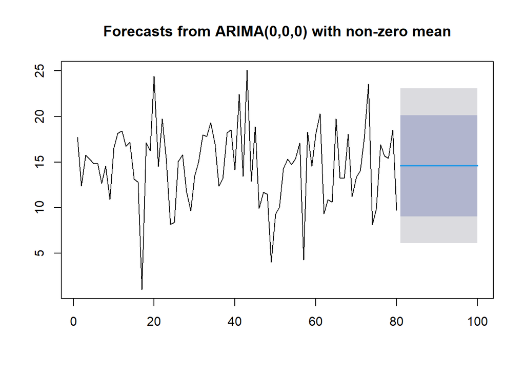

```r
data.ramalan.da <- ramalan.da$mean
plot(ramalan.da)
```

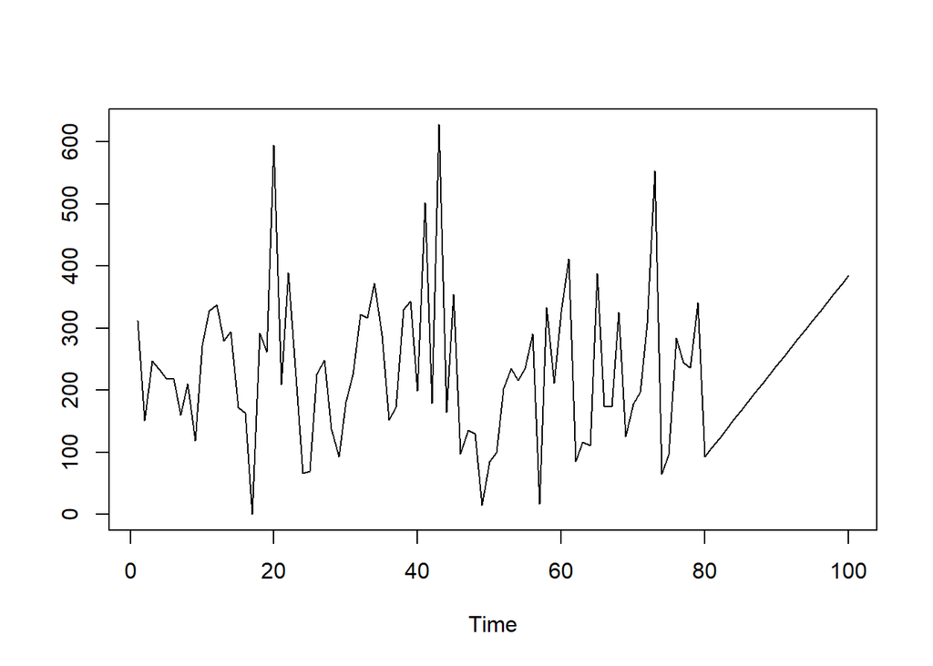

```r
pt_1 <- train.ts[80]
hasil.forc.Diff <- data.ramalan.da
hasil <- diffinv(hasil.forc.Diff, differences = 1) + pt_1
ts.plot(train.ts,hasil)
```

```r
perbandingan.da<-matrix(data=c(head(test.ts, n=20), hasil[-1]),
                     nrow = 30, ncol = 2)
colnames(perbandingan.da)<-c("Aktual","Hasil Forecast")
perbandingan.da
```

```
##         Aktual Hasil Forecast
##  [1,] 214.0700       253.7784
##  [2,] 248.7000       268.3601
##  [3,] 343.1200       282.9417
##  [4,]  63.3200       297.5234
##  [5,] 145.2900       312.1051
##  [6,] 406.2400       326.6867
##  [7,] 351.8200       341.2684
##  [8,] 109.2800       355.8501
##  [9,] 250.4400       370.4318
## [10,] 137.3000       385.0134
## [11,] 205.3500       214.0700
## [12,] 114.2100       248.7000
## [13,] 179.1500       343.1200
## [14,]  87.5900        63.3200
```

[output cut: 16 more lines]

```r
accuracy(ts(hasil[-1]), head(test.ts, n=20))
```

```
##                 ME     RMSE      MAE       MPE    MAPE      ACF1 Theil's U
## Test set -45.73355 147.6268 130.3159 -67.42642 94.4828 0.4644348 0.8055384
```